# Introduction to Data Analysis in R (1)

Irwan Rizadi

April 25, 2018

# R and I

## Education Background

S1 Statistics - UGM  
(2009 is first time know R in Computational Statistics Course)

S2 Applied Statistics - King Fahd University of Petroleum & Minerals  
(Also take R course by lecturer who is very close to founder of R, Ross Ihaka in Auckland University)

## Working Now

Data Scientist at PT. Astra International  
(Using R and some time also other tools)

# Content

## (1) Data Understanding

## (2) Data Normalization

## (3) Data Scrubbing

## (4) Handling Missing Value

## (5) Data Sampling

## (6) Dimensionality Reduction (PCA)

## (7) Data Binning

# Data Understanding

Before doin some data analysis, we have to understand what kind of data we are going to analyze. Lets take an example of exploring dataset “iris”.

```r
head(iris)
```

```
##   Sepal.Length Sepal.Width Petal.Length Petal.Width Species
## 1          5.1         3.5          1.4         0.2  setosa
## 2          4.9         3.0          1.4         0.2  setosa
## 3          4.7         3.2          1.3         0.2  setosa
## 4          4.6         3.1          1.5         0.2  setosa
## 5          5.0         3.6          1.4         0.2  setosa
## 6          5.4         3.9          1.7         0.4  setosa
```

```r
tail(iris)
```

```
##     Sepal.Length Sepal.Width Petal.Length Petal.Width   Species
## 145          6.7         3.3          5.7         2.5 virginica
## 146          6.7         3.0          5.2         2.3 virginica
## 147          6.3         2.5          5.0         1.9 virginica
## 148          6.5         3.0          5.2         2.0 virginica
## 149          6.2         3.4          5.4         2.3 virginica
## 150          5.9         3.0          5.1         1.8 virginica
```

```r
dim(iris)
```

```
## [1] 150   5
```

## Understanding Structure of Data

```r
str(iris)
```

```
## 'data.frame':    150 obs. of  5 variables:
##  $ Sepal.Length: num  5.1 4.9 4.7 4.6 5 5.4 4.6 5 4.4 4.9 ...
##  $ Sepal.Width : num  3.5 3 3.2 3.1 3.6 3.9 3.4 3.4 2.9 3.1 ...
##  $ Petal.Length: num  1.4 1.4 1.3 1.5 1.4 1.7 1.4 1.5 1.4 1.5 ...
##  $ Petal.Width : num  0.2 0.2 0.2 0.2 0.2 0.4 0.3 0.2 0.2 0.1 ...
##  $ Species     : Factor w/ 3 levels "setosa","versicolor",..: 1 1 1 1 1 1 1 1 1 1 ...
```

```r
iris$Species <- as.character(iris$Species)
str(iris)
```

```
## 'data.frame':    150 obs. of  5 variables:
##  $ Sepal.Length: num  5.1 4.9 4.7 4.6 5 5.4 4.6 5 4.4 4.9 ...
##  $ Sepal.Width : num  3.5 3 3.2 3.1 3.6 3.9 3.4 3.4 2.9 3.1 ...
##  $ Petal.Length: num  1.4 1.4 1.3 1.5 1.4 1.7 1.4 1.5 1.4 1.5 ...
##  $ Petal.Width : num  0.2 0.2 0.2 0.2 0.2 0.4 0.3 0.2 0.2 0.1 ...
##  $ Species     : chr  "setosa" "setosa" "setosa" "setosa" ...
```

```r
iris$Species <- as.factor(iris$Species)
str(iris)
```

```
## 'data.frame':    150 obs. of  5 variables:
##  $ Sepal.Length: num  5.1 4.9 4.7 4.6 5 5.4 4.6 5 4.4 4.9 ...
##  $ Sepal.Width : num  3.5 3 3.2 3.1 3.6 3.9 3.4 3.4 2.9 3.1 ...
##  $ Petal.Length: num  1.4 1.4 1.3 1.5 1.4 1.7 1.4 1.5 1.4 1.5 ...
##  $ Petal.Width : num  0.2 0.2 0.2 0.2 0.2 0.4 0.3 0.2 0.2 0.1 ...
##  $ Species     : Factor w/ 3 levels "setosa","versicolor",..: 1 1 1 1 1 1 1 1 1 1 ...
```

## Scatter plot of data

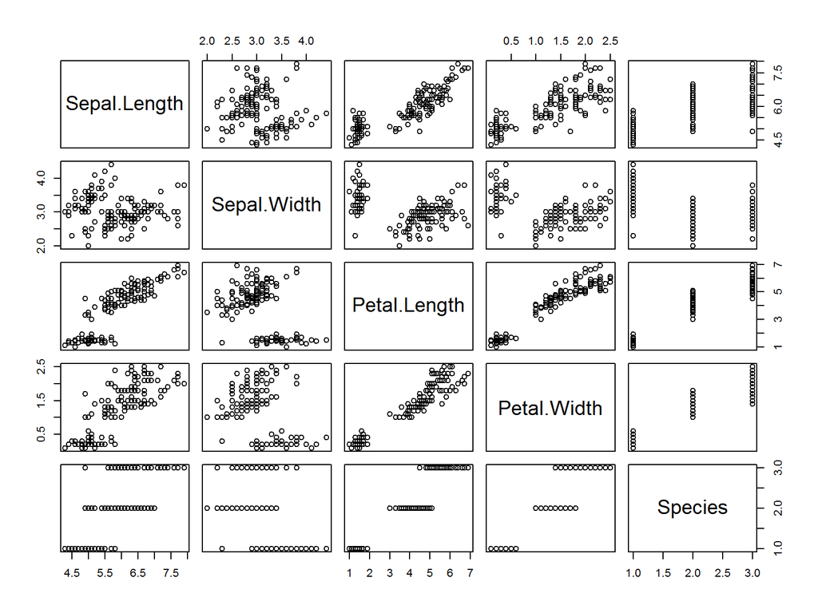

```r
pairs(iris)
```

## Correlation of Numeric variable

```r
cor(iris$Sepal.Length,iris$Petal.Length, method = "spearman")
```

```
## [1] 0.8818981
```

```r
cor(iris$Sepal.Length,iris$Petal.Length, method = "pearson")
```

```
## [1] 0.8717538
```

```r
cor(iris$Sepal.Length,iris$Petal.Length, method = "kendal")
```

```
## [1] 0.7185159
```

## Correlation of Categorical Variable

AOV : Fit an Analysis of Variance Model  
Function:  
aov(formula, data = NULL, projections = FALSE, qr = TRUE, contrasts = NULL, .)

```r
aov1 <- aov(iris$Sepal.Width~ iris$Species, data = iris)
summary(aov1)
```

```
##               Df Sum Sq Mean Sq F value Pr(>F)
## iris$Species   2  11.35   5.672   49.16 <2e-16 ***
## Residuals    147  16.96   0.115
## ---
## Signif. codes:  0 '***' 0.001 '**' 0.01 '*' 0.05 '.' 0.1 ' ' 1
```

# Data Normalization

If data of different scales are being employed by the user, it is recommended to perform a normalization to make the data structures comparable. This is performed by the Normalization function.

## Function

Normalization(Data,method=c(“Quantile”,“Fisher-Yates”,“Standardize”, “Range”,“Q”,“q”,“F”,“f”,“S”,“s”,“R”,“r”))

```r
library(IntClust)
set.seed(1234)
x=matrix(rnorm(100),ncol=10,nrow=10)
Norm_R=Normalization(x,method="R")
head(Norm_R)
```

```
##           [,1]      [,2]      [,3]      [,4]      [,5]      [,6]      [,7]
## [1,] 0.2326260 0.3817413 0.5066279 0.7044361 0.7753698 0.1102555 0.6133763
## [2,] 0.5359129 0.2752598 0.3789846 0.3820681 0.2609063 0.3603134 1.0000000
## [3,] 0.7007879 0.3206422 0.3892280 0.3342925 0.3044796 0.2526837 0.4721316
## [4,] 0.0000000 0.4924024 0.5731288 0.3768247 0.4219011 0.2718734 0.3424251
## [5,] 0.5669048 0.6752609 0.3375041 0.1464045 0.2760865 0.4460729 0.4776796
## [6,] 0.5826220 0.4567016 0.1833605 0.2406851 0.2813628 0.5942673 0.8422971
##           [,8]      [,9]     [,10]
## [1,] 0.4806415 0.4429102 0.4683728
## [2,] 0.3861796 0.4445030 0.5313706
## [3,] 0.4043513 0.1988678 0.8277670
## [4,] 0.6116802 0.4437280 0.6838455
## [5,] 0.9021960 0.6529383 0.3779840
## [6,] 0.4478935 0.6217569 0.5518733
```

```r
Norm_Quantile=Normalization(x,method="Quantile")
head(Norm_Quantile)
```

```
##            [,1]        [,2]       [,3]       [,4]       [,5]       [,6]
## [1,] -1.2070657 -0.47719270  0.1340882  1.1022975  1.4494963 -1.8060313
## [2,]  0.2774292 -0.99838644 -0.4906859 -0.4755931 -1.0686427 -0.5820759
## [3,]  1.0844412 -0.77625389 -0.4405479 -0.7094400 -0.8553646 -1.1088896
## [4,] -2.3456977  0.06445882  0.4595894 -0.5012581 -0.2806230 -1.0149620
## [5,]  0.4291247  0.95949406 -0.6937202 -1.6290935 -0.9943401 -0.1623095
## [6,]  0.5060559 -0.11028549 -1.4482049 -1.1676193 -0.9685143  0.5630558
##              [,7]         [,8]       [,9]       [,10]
## [1,]  0.656588464  0.006892838 -0.1777900 -0.05315882
## [2,]  2.548991071 -0.455468738 -0.1699941  0.25519600
## [3,] -0.034760390 -0.366523933 -1.3723019  1.70596401
## [4,] -0.669633580  0.648286568 -0.1737872  1.00151325
## [5,] -0.007604756  2.070270861  0.8502323 -0.49558344
## [6,]  1.777084448 -0.153398412  0.6976087  0.35555030
```

Try for another method by using library “clusterSim”.  
For Normalization data, we can use function from package “clusterSim” data.  
Normalization (x,type=“n0”,normalization=“column”); where type is from n0-n13  
n0 - without normalization  
n1 - standardization ((x-mean)/sd)

```r
library(clusterSim)
data(data_ratio)
```

```r
head(data_ratio)
```

```
##        v_1      v_2       v_3       v_4       v_5
## 1 4.790679 5.078952  8.485110 10.430934 13.293767
## 2 5.045025 4.951188 11.628062  9.599697 11.739800
## 3 4.729506 5.573883  8.664898  9.898832 15.153742
## 4 5.106198 4.456256 11.448274 10.131799  9.879825
## 5 6.349961 5.233782  5.437522  8.766744 12.901515
## 6 3.485743 4.796357 14.675650 11.263887 12.132052
```

```r
str(data_ratio)
```

```
## 'data.frame':    75 obs. of  5 variables:
##  $ v_1: num  4.79 5.05 4.73 5.11 6.35 ...
##  $ v_2: num  5.08 4.95 5.57 4.46 5.23 ...
##  $ v_3: num  8.49 11.63 8.66 11.45 5.44 ...
##  $ v_4: num  10.43 9.6 9.9 10.13 8.77 ...
##  $ v_5: num  13.29 11.74 15.15 9.88 12.9 ...
```

```r
z1 <- data.Normalization(data_ratio,type="n1",normalization="column")
head(z1)
```

```
##          v_1        v_2        v_3         v_4        v_5
## 1 -1.1291631 -1.0666777 -0.5434102  0.18595485  0.2824530
## 2 -1.0740316 -1.0943716  0.5840063 -0.17273705 -0.2705086
## 3 -1.1424229 -0.9593972 -0.4789177 -0.04365542  0.9443045
## 4 -1.0607718 -1.2016521  0.5195139  0.05687322 -0.9323601
## 5 -0.7911759 -1.0331168 -1.6366180 -0.53216898  0.1428746
## 6 -1.4120189 -1.1279324  1.6772141  0.54538678 -0.1309301
```

```r
z2 <- data.Normalization(data_ratio,type="n10",normalization="row")
head(z2)
```

```
##          v_1       v_2       v_3       v_4       v_5
## 1 0.11384845 0.1206991 0.2016450 0.2478867 0.3159207
## 2 0.11742509 0.1152410 0.2706481 0.2234370 0.2732488
## 3 0.10743783 0.1266191 0.1968362 0.2248668 0.3442400
## 4 0.12447356 0.1086300 0.2790740 0.2469824 0.2408400
## 5 0.16412612 0.1352765 0.1405425 0.2265922 0.3334627
## 6 0.07519882 0.1034730 0.3166016 0.2429987 0.2617279
```

# Data Scrubbing

A Utility For Basic Data Cleaning and Recoding. Changes Values Outside Of Minimum And Maximum Limits To NA.

Atedious part of data analysis is addressing the problem of miscoded data that need to be converted to NA or some other value. For a given data.frame or matrix, scrub will set all values of columns from=from to to=to that are less than a set (vector) of min values or more than a vector of max values to NA. Can also be used to do basic recoding of data for all values=isvalue to newvalue.

```r
library(psych)
```

make all occurrences of 55 NA

```r
data(attitude)
attitude
```

```
##    rating complaints privileges learning raises critical advance
## 1      43         51         30       39     61       92      45
## 2      63         64         51       54     63       73      47
## 3      71         70         68       69     76       86      48
## 4      61         63         45       47     54       84      35
## 5      81         78         56       66     71       83      47
## 6      43         55         49       44     54       49      34
## 7      58         67         42       56     66       68      35
## 8      71         75         50       55     70       66      41
## 9      72         82         72       67     71       83      31
## 10     67         61         45       47     62       80      41
## 11     64         53         53       58     58       67      34
## 12     67         60         47       39     59       74      41
## 13     69         62         57       42     55       63      25
## 14     68         83         83       45     59       77      35
```

[output cut: 16 more lines]

```r
x <- scrub(attitude,isvalue=55)
x
```

```
##    rating complaints privileges learning raises critical advance
## 1      43         51         30       39     61       92      45
## 2      63         64         51       54     63       73      47
## 3      71         70         68       69     76       86      48
## 4      61         63         45       47     54       84      35
## 5      81         78         56       66     71       83      47
## 6      43         NA         49       44     54       49      34
## 7      58         67         42       56     66       68      35
## 8      71         75         50       NA     70       66      41
## 9      72         82         72       67     71       83      31
## 10     67         61         45       47     62       80      41
## 11     64         53         53       58     58       67      34
## 12     67         60         47       39     59       74      41
## 13     69         62         57       42     NA       63      25
## 14     68         83         83       45     59       77      35
```

[output cut: 16 more lines]

will just do it for the 4th column

```r
x1 <- scrub(attitude, where=c(4,4,4), isvalue =c(30,40,50),
            newvalue = c(930,940,950))
x1
```

```
##    rating complaints privileges learning raises critical advance
## 1      43         51         30       39     61       92      45
## 2      63         64         51       54     63       73      47
## 3      71         70         68       69     76       86      48
## 4      61         63         45       47     54       84      35
## 5      81         78         56       66     71       83      47
## 6      43         55         49       44     54       49      34
## 7      58         67         42       56     66       68      35
## 8      71         75         50       55     70       66      41
## 9      72         82         72       67     71       83      31
## 10     67         61         45       47     62       80      41
## 11     64         53         53       58     58       67      34
## 12     67         60         47       39     59       74      41
## 13     69         62         57       42     55       63      25
## 14     68         83         83       45     59       77      35
```

[output cut: 16 more lines]

get rid of a complicated set of cases and replace with missing values

```r
y <- scrub(attitude,where=2:4,min=c(20,30,40),max= c(120,110,100),
           isvalue= c(32,43,54))
y
```

```
##    rating complaints privileges learning raises critical advance
## 1      43         51         30       NA     61       92      45
## 2      63         64         51       NA     63       73      47
## 3      71         70         68       69     76       86      48
## 4      61         63         45       47     54       84      35
## 5      81         78         56       66     71       83      47
## 6      43         55         49       44     54       49      34
## 7      58         67         42       56     66       68      35
## 8      71         75         50       55     70       66      41
## 9      72         82         72       67     71       83      31
## 10     67         61         45       47     62       80      41
## 11     64         53         53       58     58       67      34
## 12     67         60         47       NA     59       74      41
## 13     69         62         57       42     55       63      25
## 14     68         83         83       45     59       77      35
```

[output cut: 16 more lines]

change a column by name

```r
y1 <- scrub(attitude,where="learning",isvalue=55,newvalue=999)
y1
```

```
##    rating complaints privileges learning raises critical advance
## 1      43         51         30       39     61       92      45
## 2      63         64         51       54     63       73      47
## 3      71         70         68       69     76       86      48
## 4      61         63         45       47     54       84      35
## 5      81         78         56       66     71       83      47
## 6      43         55         49       44     54       49      34
## 7      58         67         42       56     66       68      35
## 8      71         75         50      999     70       66      41
## 9      72         82         72       67     71       83      31
## 10     67         61         45       47     62       80      41
## 11     64         53         53       58     58       67      34
## 12     67         60         47       39     59       74      41
## 13     69         62         57       42     55       63      25
## 14     68         83         83       45     59       77      35
```

[output cut: 16 more lines]

change a column by name

```r
y2 <- scrub(attitude,where="learning",min=45,newvalue=999)
y2
```

```
##    rating complaints privileges learning raises critical advance
## 1      43         51         30      999     61       92      45
## 2      63         64         51       54     63       73      47
## 3      71         70         68       69     76       86      48
## 4      61         63         45       47     54       84      35
## 5      81         78         56       66     71       83      47
## 6      43         55         49      999     54       49      34
## 7      58         67         42       56     66       68      35
## 8      71         75         50       55     70       66      41
## 9      72         82         72       67     71       83      31
## 10     67         61         45       47     62       80      41
## 11     64         53         53       58     58       67      34
## 12     67         60         47      999     59       74      41
## 13     69         62         57      999     55       63      25
## 14     68         83         83       45     59       77      35
```

[output cut: 16 more lines]

change a column by name look for multiple values in that column

```r
y3 <- scrub(attitude,where="learning",isvalue=c(45,48),
            newvalue=999)
y3
```

```
##    rating complaints privileges learning raises critical advance
## 1      43         51         30       39     61       92      45
## 2      63         64         51       54     63       73      47
## 3      71         70         68       69     76       86      48
## 4      61         63         45       47     54       84      35
## 5      81         78         56       66     71       83      47
## 6      43         55         49       44     54       49      34
## 7      58         67         42       56     66       68      35
## 8      71         75         50       55     70       66      41
## 9      72         82         72       67     71       83      31
## 10     67         61         45       47     62       80      41
## 11     64         53         53       58     58       67      34
## 12     67         60         47       39     59       74      41
## 13     69         62         57       42     55       63      25
## 14     68         83         83      999     59       77      35
```

[output cut: 16 more lines]

change values in one column to one of two different things

```r
y4 <- scrub(attitude,where="learning",isvalue=c(45,48),
            newvalue= c(999,-999))
y4
```

```
##    rating complaints privileges learning raises critical advance
## 1      43         51         30       39     61       92      45
## 2      63         64         51       54     63       73      47
## 3      71         70         68       69     76       86      48
## 4      61         63         45       47     54       84      35
## 5      81         78         56       66     71       83      47
## 6      43         55         49       44     54       49      34
## 7      58         67         42       56     66       68      35
## 8      71         75         50       55     70       66      41
## 9      72         82         72       67     71       83      31
## 10     67         61         45       47     62       80      41
## 11     64         53         53       58     58       67      34
## 12     67         60         47       39     59       74      41
## 13     69         62         57       42     55       63      25
## 14     68         83         83      999     59       77      35
```

[output cut: 16 more lines]

# Handling Missing Value

Check Missing Value

```r
y <- c(1,2,3,NA)
is.na(y)
```

```
## [1] FALSE FALSE FALSE  TRUE
```

Excluding NA from analysis

```r
mean(y) # returns NA
```

```
## [1] NA
```

```r
mean(y, na.rm=TRUE)
```

```
## [1] 2
```

## Filling Missing Value

The fill.missing function will fill the missing values within a data.frame with the values imputed with “best guess” expected values of transformed variables, back transformed to the original scale.  
Function:  
fill.missing(x, seed = 101, simplify = TRUE, idcol = “id”, …)

```r
library(nbpMatching)
set.seed(1)
df <- data.frame(id=LETTERS[1:25], val1=rnorm(25), val2=rnorm(25))
df[sample(seq_len(nrow(df)), ceiling(nrow(df)*0.1)), 2] <- NA
df
```

```
##    id        val1        val2
## 1   A -0.62645381 -0.05612874
## 2   B  0.18364332 -0.15579551
## 3   C -0.83562861 -1.47075238
## 4   D  1.59528080 -0.47815006
## 5   E  0.32950777  0.41794156
## 6   F -0.82046838  1.35867955
## 7   G          NA -0.10278773
## 8   H  0.73832471  0.38767161
## 9   I          NA -0.05380504
## 10  J -0.30538839 -1.37705956
## 11  K  1.51178117 -0.41499456
## 12  L  0.38984324 -0.39428995
## 13  M -0.62124058 -0.05931340
## 14  N -2.21469989  1.10002537
## 15  O  1.12493092  0.76317575
## 16  P -0.04493361 -0.16452360
## 17  Q          NA -0.25336168
## 18  R  0.94383621  0.69696338
## 19  S  0.82122120  0.55666320
## 20  T  0.59390132 -0.68875569
## 21  U  0.91897737 -0.70749516
## 22  V  0.78213630  0.36458196
## 23  W  0.07456498  0.76853292
## 24  X -1.98935170 -0.11234621
## 25  Y  0.61982575  0.88110773
```

```r
df <- fill.missing(df)
df
```

```
##    id        val1        val2 val1.missing
## 1   A -0.62645381 -0.05612874            0
## 2   B  0.18364332 -0.15579551            0
## 3   C -0.83562861 -1.47075238            0
## 4   D  1.59528080 -0.47815006            0
## 5   E  0.32950777  0.41794156            0
## 6   F -0.82046838  1.35867955            0
## 7   G  1.59528080 -0.10278773            1
## 8   H  0.73832471  0.38767161            0
## 9   I  1.59528080 -0.05380504            1
## 10  J -0.30538839 -1.37705956            0
## 11  K  1.51178117 -0.41499456            0
## 12  L  0.38984324 -0.39428995            0
## 13  M -0.62124058 -0.05931340            0
## 14  N -2.21469989  1.10002537            0
## 15  O  1.12493092  0.76317575            0
## 16  P -0.04493361 -0.16452360            0
## 17  Q  1.59528080 -0.25336168            1
## 18  R  0.94383621  0.69696338            0
## 19  S  0.82122120  0.55666320            0
## 20  T  0.59390132 -0.68875569            0
## 21  U  0.91897737 -0.70749516            0
## 22  V  0.78213630  0.36458196            0
## 23  W  0.07456498  0.76853292            0
## 24  X -1.98935170 -0.11234621            0
## 25  Y  0.61982575  0.88110773            0
```

## Other Example

```r
data("airquality")
head(airquality, 3)
```

```
##   Ozone Solar.R Wind Temp Month Day
## 1    41     190  7.4   67     5   1
## 2    36     118  8.0   72     5   2
## 3    12     149 12.6   74     5   3
```

### Explore Missing Value

```r
library(mice)
md.pattern(airquality)
```

```
##     Wind Temp Month Day Solar.R Ozone
## 111    1    1     1   1       1     1  0
##  35    1    1     1   1       1     0  1
##   5    1    1     1   1       0     1  1
##   2    1    1     1   1       0     0  2
##        0    0     0   0       7    37 44
```

From the output, we can see that 111 row completed, 35 missing in ozone and 5 missing in solar.

### Visualization of missing value

```r
library(colorspace)
library(grid)
library(data.table)
library(VIM)
```

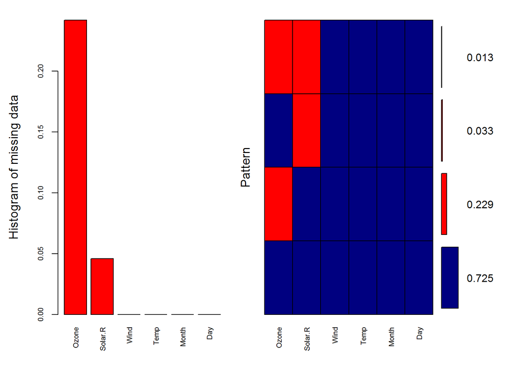

```
##
##  Variables sorted by number of missings:
##  Variable      Count
##     Ozone 0.24183007
##   Solar.R 0.04575163
##      Wind 0.00000000
##      Temp 0.00000000
##     Month 0.00000000
##       Day 0.00000000
```

```r
aggr_plot <- aggr(airquality, col=c('navyblue','red'), numbers=TRUE, sortVars=TRUE, labels=names(airquality), cex.axis=.7,gap=3, ylab=c("Histogram of missing data","Pattern"))
```

From the output, navyblue is not missing and red is missing

### Imputing Missing value

Function:  
mice(data, m = 5, method = vector(“character”, length = ncol(data)), predictorMatrix = (1 - diag(1, ncol(data))), where = is.na(data), visitSequence = NULL, form = vector(“character”, length = ncol(data)), post = vector(“character”, length = ncol(data)), defaultMethod = c(“pmm”, “logreg”, “polyreg”, “polr”), maxit = 5, diagnostics = TRUE, printFlag = TRUE, seed = NA, imputationMethod = NULL, defaultImputationMethod = NULL, data.init = NULL, …)

We can use method PMM : predictive mean matching in mice package. PMM use numeric data.  
Logreg, logistic regression imputation (binary data, factor with 2 levels)  
polyreg,polytomous regression imputation for unordered categorical data(factor >= 2 levels)  
polr, proportional odds model for (ordered, >= 2 levels)

```r
tempData <- mice(airquality,m=5,maxit=50,meth='pmm',seed=500)
summary(tempData)
```

```
## Multiply imputed data set
## Call:
## mice(data = airquality, m = 5, method = "pmm", maxit = 50, seed = 500)
## Number of multiple imputations:  5
## Missing cells per column:
##   Ozone Solar.R    Wind    Temp   Month     Day
##      37       7       0       0       0       0
## Imputation methods:
##   Ozone Solar.R    Wind    Temp   Month     Day
##   "pmm"   "pmm"   "pmm"   "pmm"   "pmm"   "pmm"
## VisitSequence:
##   Ozone Solar.R
##       1       2
## PredictorMatrix:
##         Ozone Solar.R Wind Temp Month Day
## Ozone       0       1    1    1     1   1
## Solar.R     1       0    1    1     1   1
## Wind        0       0    0    0     0   0
## Temp        0       0    0    0     0   0
## Month       0       0    0    0     0   0
## Day         0       0    0    0     0   0
## Random generator seed value:  500
```

Data Imputed

```r
completedData <- complete(tempData,1)
```

Recheck missing value

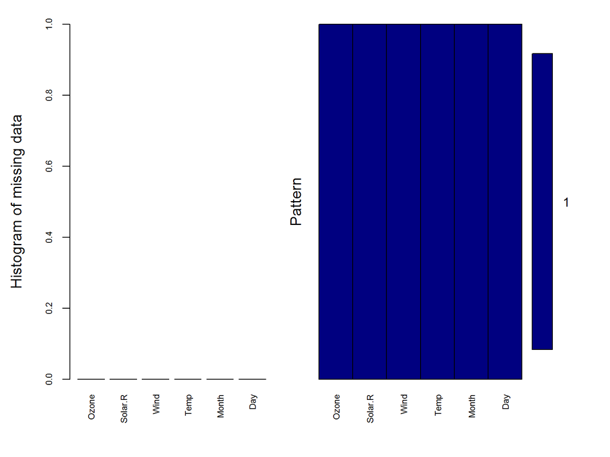

```
##
##  Variables sorted by number of missings:
##  Variable Count
##     Ozone     0
##   Solar.R     0
##      Wind     0
##      Temp     0
##     Month     0
##       Day     0
```

```r
aggr_plot2 <- aggr(completedData, col=c('navyblue','red'), numbers=TRUE,
                   sortVars=TRUE, labels=names(completedData),
                   cex.axis=.7, gap=3,
                   ylab=c("Histogram of missing data","Pattern"))
```

# Data Sampling

Define Mean, Standard Deviation, and size of sample we will collect from the population

```r
popMean = 100
popSD = 15
sampSize = 30
```

Create Population Data size 1 Million

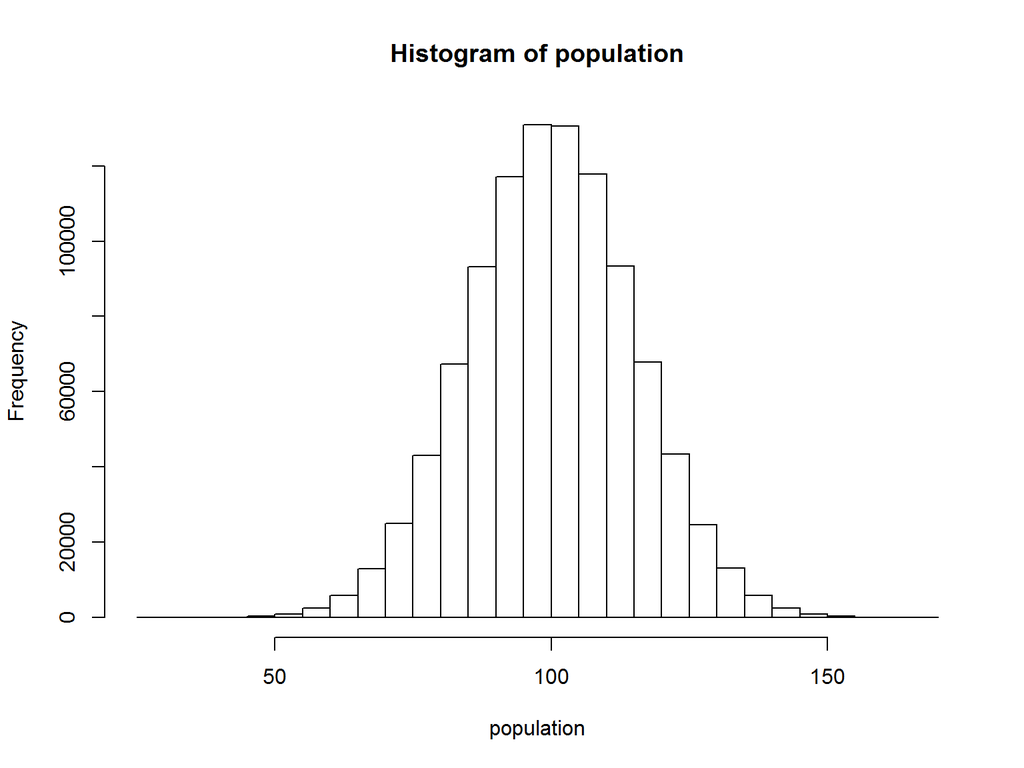

```r
population <- rnorm(1000000, mean = popMean, sd = popSD)
hist(population)
```

Mean and Standard Deviation of Population

```r
mean(population)
```

```
## [1] 100.0195
```

```r
sd(population)
```

```
## [1] 14.98746
```

Sample mean are unbiased estimator of population mean.  
Create 30 Sample using simple random sampling with replacement

```r
sampDist <- replicate(10000,mean(sample(population, sampSize, replace=TRUE)))
mean(sampDist)
```

```
## [1] 99.99904
```

```r
sdDist_2 <- replicate(10000,sd(sample(population, sampSize, replace=TRUE)))
mean(sdDist_2)
```

```
## [1] 14.83413
```

Take 75% and 25% of sample from dataset

```r
data(mtcars)
#
set.seed(123)
smp_size <- floor(0.75 * nrow(mtcars))
mtcars_75 <- sample(seq_len(nrow(mtcars)), size = smp_size)
mtcars[mtcars_75,]
```

```
##                      mpg cyl  disp  hp drat    wt  qsec vs am gear carb
## Merc 280            19.2   6 167.6 123 3.92 3.440 18.30  1  0    4    4
## Pontiac Firebird    19.2   8 400.0 175 3.08 3.845 17.05  0  0    3    2
## Merc 450SL          17.3   8 275.8 180 3.07 3.730 17.60  0  0    3    3
## Fiat X1-9           27.3   4  79.0  66 4.08 1.935 18.90  1  1    4    1
## Porsche 914-2       26.0   4 120.3  91 4.43 2.140 16.70  0  1    5    2
## Mazda RX4 Wag       21.0   6 160.0 110 3.90 2.875 17.02  0  1    4    4
## Merc 450SLC         15.2   8 275.8 180 3.07 3.780 18.00  0  0    3    3
## AMC Javelin         15.2   8 304.0 150 3.15 3.435 17.30  0  0    3    2
## Ford Pantera L      15.8   8 351.0 264 4.22 3.170 14.50  0  1    5    4
## Merc 280C           17.8   6 167.6 123 3.92 3.440 18.90  1  0    4    4
## Dodge Challenger    15.5   8 318.0 150 2.76 3.520 16.87  0  0    3    2
## Volvo 142E          21.4   4 121.0 109 4.11 2.780 18.60  1  1    4    2
## Camaro Z28          13.3   8 350.0 245 3.73 3.840 15.41  0  0    3    4
## Maserati Bora       15.0   8 301.0 335 3.54 3.570 14.60  0  1    5    8
## Lotus Europa        30.4   4  95.1 113 3.77 1.513 16.90  1  1    5    2
## Lincoln Continental 10.4   8 460.0 215 3.00 5.424 17.82  0  0    3    4
## Hornet 4 Drive      21.4   6 258.0 110 3.08 3.215 19.44  1  0    3    1
## Mazda RX4           21.0   6 160.0 110 3.90 2.620 16.46  0  1    4    4
## Hornet Sportabout   18.7   8 360.0 175 3.15 3.440 17.02  0  0    3    2
## Ferrari Dino        19.7   6 145.0 175 3.62 2.770 15.50  0  1    5    6
## Honda Civic         30.4   4  75.7  52 4.93 1.615 18.52  1  1    4    2
## Merc 240D           24.4   4 146.7  62 3.69 3.190 20.00  1  0    4    2
## Duster 360          14.3   8 360.0 245 3.21 3.570 15.84  0  0    3    4
## Merc 230            22.8   4 140.8  95 3.92 3.150 22.90  1  0    4    2
```

```r
mtcars[-mtcars_75,]
```

```
##                     mpg cyl  disp  hp drat    wt  qsec vs am gear carb
## Datsun 710         22.8   4 108.0  93 3.85 2.320 18.61  1  1    4    1
## Valiant            18.1   6 225.0 105 2.76 3.460 20.22  1  0    3    1
## Merc 450SE         16.4   8 275.8 180 3.07 4.070 17.40  0  0    3    3
## Cadillac Fleetwood 10.4   8 472.0 205 2.93 5.250 17.98  0  0    3    4
## Chrysler Imperial  14.7   8 440.0 230 3.23 5.345 17.42  0  0    3    4
## Fiat 128           32.4   4  78.7  66 4.08 2.200 19.47  1  1    4    1
## Toyota Corolla     33.9   4  71.1  65 4.22 1.835 19.90  1  1    4    1
## Toyota Corona      21.5   4 120.1  97 3.70 2.465 20.01  1  0    3    1
```

# PCA (Dimensional Reduction)

Dimension reduction is the process of reducing the number of random variables under consideration by obtaining a set of principal variables.

Load Library

```r
library(lattice)
library(ggplot2)
library(caret)
library(e1071)
```

Load Data

```r
data("iris")
head(iris,3)
```

```
##   Sepal.Length Sepal.Width Petal.Length Petal.Width Species
## 1          5.1         3.5          1.4         0.2  setosa
## 2          4.9         3.0          1.4         0.2  setosa
## 3          4.7         3.2          1.3         0.2  setosa
```

PCA Function

```r
trans <- preProcess(iris[,1:4],
                   method=c("BoxCox", "center",
                            "scale", "pca"))
```

Hasil pca

```r
PC <- predict(trans, iris[,1:4])
head(PC,3)
```

```
##         PC1        PC2
## 1 -2.303540 -0.4748260
## 2 -2.151310  0.6482903
## 3 -2.461341  0.3463921
```

# Data Binning

“Discretizes all numerical data in a data frame into categorical bins of equal length or content or based on automatically determined clusters”

## Function

“bin(data, nbins = 5, labels = NULL, method = c(”length“,”content“,”clusters“), na.omit = TRUE)”

When “na.omit = FALSE” an additional level “NA” is added to each factor with missing values.

```r
library(OneR)
```

## Difference between methods “length”, “content”, and “clusters”

### Method “length”

```r
data(faithful)
head(faithful)
```

```
##   eruptions waiting
## 1     3.600      79
## 2     1.800      54
## 3     3.333      74
## 4     2.283      62
## 5     4.533      85
## 6     2.883      55
```

```r
table(bin(faithful$waiting, nbins = 3, method = "length"))
```

```
##
## (42.9,60.7] (60.7,78.3] (78.3,96.1]
##          83          87         102
```

### Method “content”

```r
table(bin(faithful$waiting, nbins = 3, method = "content"))
```

```
##
## (42.9,64]   (64,80] (80,96.1]
##        94        94        84
```

### Method “clusters”

```r
table(bin(faithful$waiting, nbins = 3, method = "clusters"))
```

```
##
## (42.9,64.4] (64.4,79.6] (79.6,96.1]
##          94          86          92
```

# Question?

## QUIZ data analysis using data camera.csv